# Assessment

2025-11-12

This project aims to look at trends in the prescribing of dry eye disease medication in Scotland by seasons, rurality, sex, and age.

Introduction-

Dry eye is a condition of various aetiologies which causes ocular surface inflammation and corneal and conjunctival epithelial cell damage [1], [2], [3]. Symptoms include irritation, grittiness, burning, soreness, watery eyes and visual disturbances potentially affecting one or both eyes (Bilkhu).

Dry eye is initiated through mechanisms of tear film hyper-osmolarity and tear film instability [1] and can be broadly divided in to two types, aqueous deficiency and evaporative dry eye. (Bilkhu)

Global DED prevalence is estimated to range from 5% to 50%,2 with estimates in Europe ranging from 10% to 30% (Hossain).

However, it is expected that the number of dry eye patients encountered in UK clinical practice may increase with an aging population. (Bilkhu)

Prevalence of DED in the UK is higher in women compared with men and increases with age, with the majority of individuals with DED aged >50 years (Hossain).

DED is a major cause for prescribing in primary medical care in the National Health Service in England. In 2014, over 6.4 million prescription items for DED (ie, artificial tears, ocular lubricants and astringents) were dispensed in the community at a cost of more than £27 million to the National Health Service (Hossain).

In a systematic literature search supplemented with information from interviews of ophthalmologists, the annual healthcare costs for 1000 patients with DED who were managed by ophthalmologists in the UK were estimated to be US$1.10 million (2003/2004 prices), with almost one-half of the total attributed to prescription drug costs. Some patients suffering from DED self-treat their symptoms with over-the-counter artificial tears or are treated by general practitioners/optometrists/pharmacists; thus, annual costs could be higher as only reimbursed treatments prescribed by ophthalmologists were captured in this estimate (Hossain).

```r
 # Load required packages
library(tidyverse)
library(janitor)
library(gt)
library(scales)
library(here)
```

# Sourcing the raw data

The files are downloaded from the Prescriptions in the Community page from Public Health Scotland. The data selected and downloaded are the Data by Prescriber Location from January 2022 to Decemeber 2024, in order to show more comprehensive data over several years. They are then put into the prescribing_data subfolder within the data folder.

In order to determine which prescriptions are related to DED, the BNF Code Information (accessible here: https://opendata.nhsbsa.net/dataset/bnf-code-information-current-year) can be used to filter for Tear deficiency, eye lubricant and astringent within BNF_PARAGRAPH. From this, it can be determined that these DED medications’ BNFItemCode in prescribing_data begin with ‘110801’.

```r
# Here the data is loaded programatically instead of manually which keeps the coding more DRY and makes it easier for future months to be added and analysed.

prescribing_data <- list.files("data/prescribing_data", full.names = TRUE) %>%
  set_names() %>%
  map(~ read_csv(.x) %>%
  rename(any_of(c(HBT = "HBT2014"))) %>% # Some of the Data by Prescriber Location files' column for their healthboard is named HBT2014 which means they must be renamed in order to be later combined into a single dataframe.
  select(HBT, BNFItemCode, BNFItemDescription, GPPractice, NumberOfPaidItems, PaidQuantity, GrossIngredientCost, PaidDateMonth)) # Selecting only the columns relevant to the study and for cleaner data.

ded_prescriptions <- prescribing_data %>%
  map(~ .x %>% filter(grepl("110801", BNFItemCode))) %>% # This allows to filter only for the DED prescriptions, which BNFItemCode begins with 110801.
  bind_rows() %>%
  clean_names()
```

# Seasonal Variation

It has been shown that patients who participate in over four hours of outdoor activity on a weekend day are 2.4 times more likely to experience DED. This is likely due to a variety of factors related to the environmental impact of the outdoors, such as, temperature, humidity, wind, precipitation, sunlight exposure, and air pollution. Moreover, it has been shown that any allergy, which often are exacerbated seasonally, are significant risk factors of DED (vidal-rohr). This raises the question of if, and how seasonality and climate can affect the prescriptions of DED medication, and can be useful data for clinicians and pharmacists to predict variations in the amount of medication they may have to prescribe over the year.

The DED prescriptions data includes information on which month and year it was prescribed, which can be used to be stratified into each month. By grouping by month, it can be determined how many items were prescribed (the column of paid_quantity) in each month. Furthermore, these months can be assigned into the four seasons which allow for a clean final visualisation. Finally, using a trend line via geom_smooth() allows for the overall trend to be observed.

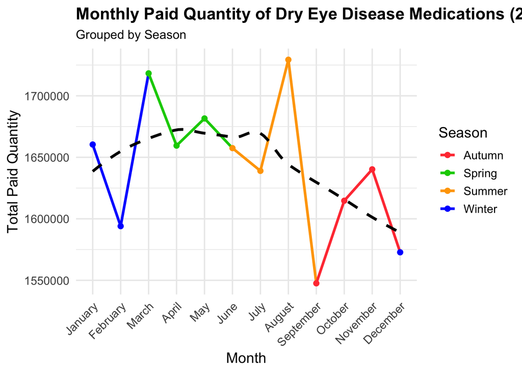

```r
ded_seasonal_summary <- ded_prescriptions %>%
  mutate(month = paid_date_month %% 100, month_name = case_when(
    month == 1  ~ "January",
    month == 2  ~ "February",
    month == 3  ~ "March",
    month == 4  ~ "April",
    month == 5  ~ "May",
    month == 6  ~ "June",
    month == 7  ~ "July",
    month == 8  ~ "August",
    month == 9  ~ "September",
    month == 10 ~ "October",
    month == 11 ~ "November",
    month == 12 ~ "December")) %>%
  group_by(month_name, month) %>%
    summarise(total_paid_quantity = sum(paid_quantity)) %>%
  mutate(month_name = factor(month_name, levels = c("January", "February", "March", "April", "May", "June", "July", "August", "September", "October", "November", "December")),
         season = case_when(
           month %in% c(3, 4, 5)  ~ "Spring",
           month %in% c(6, 7, 8)  ~ "Summer",
           month %in% c(9, 10, 11) ~ "Autumn",
           month %in% c(12, 1, 2) ~ "Winter"))

ggplot(ded_seasonal_summary, aes(x = month_name, y = total_paid_quantity, group = 1, color = season)) +
  geom_line(size = 1.2) +
  geom_point(size = 2) +
  scale_color_manual(values = c("Spring" = "green3", "Summer" = "orange", "Autumn" = "brown1", "Winter" = "blue")) +
  labs(
    title = "Monthly Paid Quantity of Dry Eye Disease Medications (2022-2024)",
    subtitle = "Grouped by Season",
    x = "Month",
    y = "Total Paid Quantity",
    color = "Season") +
  theme_minimal(base_size = 14) +
  theme(
    axis.text.x = element_text(angle = 45, hjust = 1),
    plot.title = element_text(face = "bold", size = 16),
    plot.subtitle = element_text(size = 12)) +
  geom_smooth(aes(group = 1), method = "loess", se = FALSE, linetype = "dashed", color = "black")
```

It can be hypothesised that during the winter months there could be a peak due to the colder, dryer air, however, patients may be less inclined to be outdoors for prolonged periods of time. During the spring months when allergies begin to spike, not only could the allergies worsen symptoms, but patients could begin spending more time outdoors. Moving into summer, patients will likely be spending the most time exposed to the outdoors, with the most sunlight exposure and warmest weather. Finally in Autumn, there will be less time spent outdoors as temperatures drop again.

Of course there are limitations in what can be observed from this graph and it is difficult to truly draw conclusions on why this seasonal variation is happening. There are geographical variations across Scotland geographically, with regions experiencing different climates and exposures which is difficult to determine from this data. Further research into seasonal behavioural trends related to outdoor exposure and DED in Scotland could reveal interesting patterns to better explain these variations.

# Rurality

To try and answer this question of how geographical variations in Scotland can affect DED, examining further than just seasonality can be particularly useful. It is established that air pollution and outdoor exposure are risk factors of DED (vidal-rohr), and whether a patient lives in a rural or urban setting could have significant implications on their exposures to these risk factors, and therefore, whether they develop it. It is key for prescribers to understand the demographics of different geographical areas as trends seen in patients could largely vary across Scotland.

The 2 raw data are sourced from Public Health Scotland from GP Practice List Page January 2025 (in order to ensure all practices are included in 2024.) and the Urban Rural 2020 Fold, which are then joined together.

```r
gp_details <- read_csv("data/gp_details/0d2e258a-1451-4af1-a7e5-e8327994fa55.csv") %>%
  select(PracticeCode, DataZone, PracticeListSize) %>%
  clean_names()

urban_rural <- read_csv("data/urban_rural/c8bd76cd-6613-4dd7-8a28-6c99a16dc678.csv") %>%
  select(DataZone, UrbanRural6fold2020) %>%
  clean_names()

gp_rurality <- inner_join(gp_details, urban_rural, by = "data_zone")
```

From the DED prescriptions data, the prescriptions are stratified by GP Practice to determine the total number of DED items prescribed by each practice. This can then be joined with the GP and rurality data to determine the number of DED prescriptions in each GP practice and what fold their rurality is in the Urban Rural 6 Fold 2020. Finally, once stratified by Urban Rural Fold, the practice population of each fold, how many DED items were prescribed, and the number of items prescribed per person can be determined and visually displayed as a table.

```r
ded_prescriptions_by_gp <- ded_prescriptions %>%
  group_by(gp_practice) %>%
  summarise(total_paid_quantity = sum(paid_quantity, na.rm = TRUE))

ded_prescriptions_rurality <- full_join(ded_prescriptions_by_gp, gp_rurality, by = c("gp_practice" = "practice_code")) %>%
  filter(!is.na(urban_rural6fold2020)) %>%
  group_by(urban_rural6fold2020) %>%
  summarise(total_paid_quantity = sum(total_paid_quantity, na.rm = TRUE), total_practice_list_size = sum(practice_list_size, na.rm = TRUE)) %>%
  mutate(proportion_quantity = total_paid_quantity / total_practice_list_size, itemsperperson = total_paid_quantity / total_practice_list_size, urban_rural6fold2020 = factor(urban_rural6fold2020, levels = 1:6, labels = c("Large Urban Areas [1]", "Other Urban Areas [2]", "Accessible Small Towns [3]", "Remote Small Towns [4]", "Accessible Rural [5]", "Remote Rural [6]")))

ded_prescriptions_rurality %>%
  select(urbanrural = urban_rural6fold2020, total_items = total_paid_quantity, total_population = total_practice_list_size, itemsperperson) %>%
  gt() %>%
  tab_header(
    title = md("**Dry Eye Medication Prescribing by Urban–Rural Classification**"),
    subtitle = "Standardised by practice list size, Scotland (2024)") %>%
  fmt_number(
    columns = c(total_items, total_population),
    decimals = 0,
    use_seps = TRUE) %>%
  fmt_number(
    columns = itemsperperson,
    decimals = 3) %>%
  cols_label(
    urbanrural = "Urban/Rural Category",
    total_items = "Total DED Items Prescribed",
    total_population = "Total Practice Population",
    itemsperperson = "Items per Person") %>%
  tab_style(
    style = list(cell_text(weight = "bold")), locations = cells_title(groups = "title")) %>%
  tab_style(
    style = cell_borders(sides = "bottom", color = "black", weight = px(2)),
    locations = cells_column_labels()) %>%
  tab_options(
    table.font.size = 14,
    column_labels.background.color = "#f0f0f0",
    data_row.padding = px(6),
    table.border.top.color = "white",
    table.border.bottom.color = "white",
    heading.title.font.size = 20,
    heading.subtitle.font.size = 14)
```

**Dry Eye Medication Prescribing by Urban–Rural Classification**

| Urban/Rural Category | Total DED Items Prescribed | Total Practice Population | Items per Person |
| --- | --- | --- | --- |
| Large Urban Areas [1] | 6,068,190 | 2,455,496 | 2.471 |
| Other Urban Areas [2] | 6,523,303 | 2,230,321 | 2.925 |
| Accessible Small Towns [3] | 1,517,312 | 518,643 | 2.926 |
| Remote Small Towns [4] | 829,801 | 213,634 | 3.884 |
| Accessible Rural [5] | 1,162,356 | 373,783 | 3.110 |
| Remote Rural [6] | 707,232 | 237,342 | 2.980 |

The results of the table are interesting, it may have been expected that urban areas may result in greater numbers of prescriptions per person due to air pollution, however the impact of this may be limited due to Scotland having less of a pollution problem than other cities worldwide, meaning the relative difference between urban and rural is not significant enough to impact this. It would also be expected that in urban areas there could potentially be better access to healthcare resources, resulting in greater prescriptions per person, however, this is not observed. The prescriptions per person in smaller towns or rural areas being on average higher than urban areas (3.2 > 2.7) supports the narrative that outdoor exposure is a significant risk factor for DED as these patients may have better access to outdoor activities resulting in greater time spent exposed outdoors.

# Demographics

While geographical location and climate play key roles in the exposure of significant risk factors, specific demographics have also been shown to play key a role in the prevelance of DED across Scotland. In particular, sex and age (Hossain). It has been shown there are male-specific sex hormones which help regulate both tear lipid and aqueous secretions, as well as the immune responses of corneal and conjunctival cells. Whereas in females, these specific sex hormones antagonise these functions. As a result, females are shown to be 2.4 times more significantly likely to experience DED than males (vidal-rohr). Moreover, the majority of individuals with DED are aged >50 years (Hossain), and as Scotland has an aging population, the effects of this can be profound.

The data is sourced from the practice populations information from Public Health Scotland.

```r
practice_populations <- read_csv("data/practice_populations/ce967fa9-0f7f-4389-9f19-4958c45e43c2.csv") %>%
  clean_names()
```

## Sex

Using the DED prescription data, it is filtered for only the items prescribed in 2024 in order to better represent the average number of prescriptions per person from the current 2025 January practice data. The practice population is then stratified by sex and GP practice and then transformed from long format to wide format using pivot_wider(). By transforming, the Male and Female sex can become columns and allows for the number of patients of each sex in each GP practice to be compared. A ratio can then be calculated for the female to male ratio in each GP practice, which can be used as the x-axis for a plot. This dataframe can then be joined to the DED prescription data for 2024, in order to determine the number of DED items prescribed per patient of each GP practice. When plotted on a graph, a log scale can be used which prevents extremes that might stretch the plot and makes the trends more easy to see. What can then be observed is how the ratio of female-to-male in a gp practice may impact the number of DED prescriptions per person.

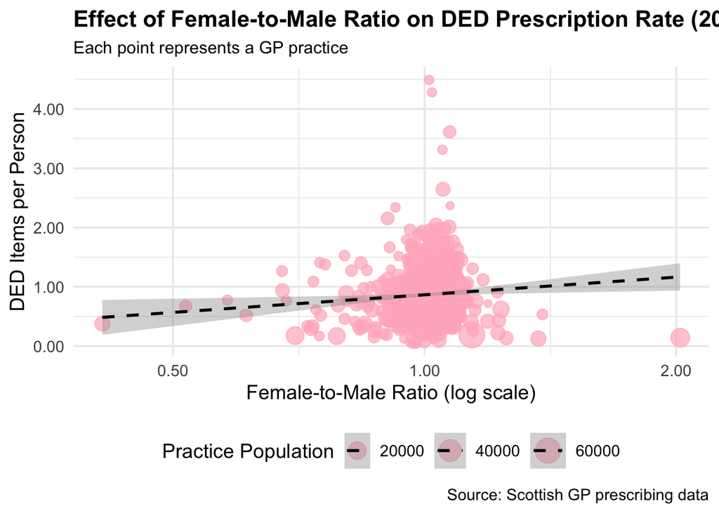

```r
ded_by_gp_2024 <- ded_prescriptions %>%
  filter(str_starts(as.character(paid_date_month), "2024")) %>%
  group_by(gp_practice) %>%
  summarise(total_paid_quantity = sum(paid_quantity, na.rm = TRUE))

sex_population <- practice_populations %>%
    group_by(sex, practice_code) %>%
    summarise(total_all_ages = sum(all_ages, na.rm = TRUE)) %>%
    pivot_wider(names_from = sex, values_from = total_all_ages) %>%
    mutate(female_to_male_ratio = Female / Male) %>%
    filter(!is.na(female_to_male_ratio))

ded_per_sex_gp_2024 <- inner_join(ded_by_gp_2024, sex_population, by = c("gp_practice" = "practice_code")) %>%
  mutate(rate_per_person = total_paid_quantity / All)

ggplot(ded_per_sex_gp_2024, aes(x = female_to_male_ratio, y = rate_per_person, size = All)) +
  geom_point(color = "pink1", alpha = 0.7) +
  geom_smooth(method = "lm", se = TRUE, color = "black", linetype = "dashed", linewidth = 1) +
  scale_x_log10(labels = scales::comma_format(accuracy = 0.01)) +  # Prevents extreme ratios from stretching the plot and makes trends easier to see.
  scale_y_continuous(labels = scales::comma_format(accuracy = 0.01)) +
  scale_size_continuous(name = "Practice Population", range = c(2, 8)) +
  labs(
    title = "Effect of Female-to-Male Ratio on DED Prescription Rate (2024)",
    subtitle = "Each point represents a GP practice",
    x = "Female-to-Male Ratio (log scale)",
    y = "DED Items per Person",
    caption = "Source: Scottish GP prescribing data"
  ) +
  theme_minimal(base_size = 14) +
  theme(
    plot.title = element_text(face = "bold", size = 16),
    plot.subtitle = element_text(size = 12),
    legend.position = "bottom"
  )
```

What can be observed is a slight positive relationship. As the ratio of female to male increases in GP practices, there is an increase in the prescription of DED items across GP practices, supporting the evidence that females are more likely to have DED.

## Age

```r
hb_pop_normalised <- practice_populations %>%
  rowwise() %>%
  mutate(
    weighted_age = (ages0to4*2.5 + ages5to14*10 + ages15to24*20 + ages25to44*34.5 + ages45to64*54.5 + ages65to74*69.5 + ages75to84*79.5 + ages85plus*90) / all_ages)

joined_hbt_DED <- inner_join(ded_by_gp_2024, hb_pop_normalised, by = c("gp_practice" = "practice_code")) %>%
  filter(sex == "All") %>%
  mutate(rate_per_person = total_paid_quantity / all_ages) %>%
    filter(!is.na(weighted_age))
```

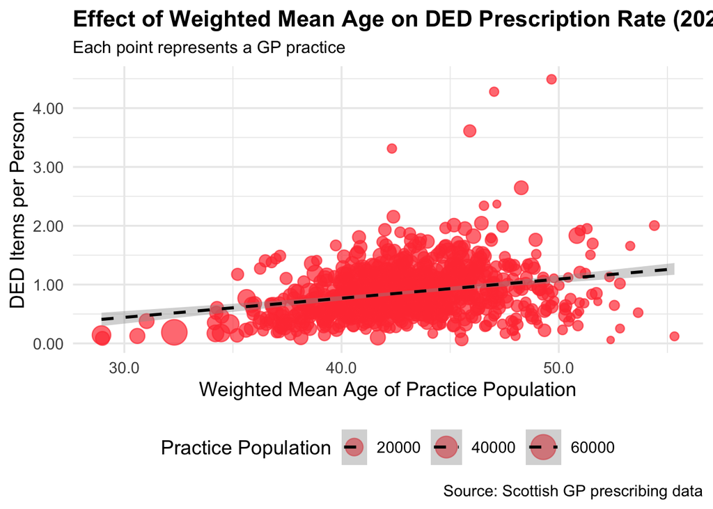

```r
ggplot(joined_hbt_DED, aes(x = weighted_age, y = rate_per_person, size = all_ages)) +
  geom_point(color = "brown1", alpha = 0.7) +
  geom_smooth(method = "lm", se = TRUE, color = "black", linetype = "dashed", linewidth = 1) +
  scale_x_continuous(labels = scales::comma_format(accuracy = 0.1)) +
  scale_y_continuous(labels = scales::comma_format(accuracy = 0.01)) +
  scale_size_continuous(name = "Practice Population", range = c(2, 8)) +
  labs(
    title = "Effect of Weighted Mean Age on DED Prescription Rate (2024)",
    subtitle = "Each point represents a GP practice",
    x = "Weighted Mean Age of Practice Population",
    y = "DED Items per Person",
    caption = "Source: Scottish GP prescribing data"
  ) +
  theme_minimal(base_size = 14) +
  theme(
    plot.title = element_text(face = "bold", size = 16),
    plot.subtitle = element_text(size = 12),
    legend.position = "bottom"
  )
```